# Ramsudhan_Ketharnathan_8919268_Section-2_Midterm

Data Preprocessing Tasks (21 Points):

1. (4 points) Detect and handle outliers for the “median_house_value” field using:

   a. Apply the whiskers approach to identify outlier rows.

```python
import pandas as pd

# TASK 1: Loading dataset
data = pd.read_csv("C:/Users/91902/Downloads/housing_dataset.csv")

# TASK 2: Calculating IQR for 'median_house_value'
Q1 = data['median_house_value'].quantile(0.25)

Q3 = data['median_house_value'].quantile(0.75)

IQR = Q3 - Q1

# TASK 3: Define lower and upper bounds for outliers
lwr_bound = Q1 - 1.5 * IQR

upr_bound = Q3 + 1.5 * IQR

# TASK 4: Detecting outliers
outliers = data[(data['median_house_value'] < lwr_bound) | (data['median_house_value'] > upr_bound)]

print("Outliers- whiskers approach:")

#output
print(outliers)
```

```
Outliers- whiskers approach:
       longitude  latitude  housing_median_age  total_rooms  total_bedrooms  \
19568    -118.37     33.81                33.0       5057.0           790.0
19569    -117.19     32.69                35.0       2921.0           438.0
19570    -117.87     33.60                34.0       3415.0           779.0
19571    -118.59     34.14                19.0       1303.0           155.0
19572    -122.18     37.81                30.0        292.0            38.0
...          ...       ...                 ...          ...             ...
20635    -118.90     34.14                35.0       1503.0           263.0
20636    -118.69     34.18                11.0       1177.0           138.0
20637    -118.80     34.19                 4.0      15572.0          2222.0
20638    -118.69     34.21                10.0       3663.0           409.0
20639    -118.85     34.27                50.0        187.0            33.0

       population  households  median_income  median_house_value  \
```

[output cut: 26 more lines]

```
 b.Apply Z-score normalization and choose appropriate threshold to match the outliers from the whiskers approach
```

```python
import numpy as np

# TASK 1: Calculating the Z-scores for 'median_house_value'
mean = data['median_house_value'].mean()

std_dev = data['median_house_value'].std()

data['z_score'] = (data['median_house_value'] - mean) / std_dev

# Print the Z-scores
print("Z-scores for 'median_house_value':")

print(data['z_score'])

# TASK 2: Define the Z-score threshold
z_score_threshold = 2.0  # 2 from considering whisker's approach

# TASK 3: Identifying outliers based on the Z-score threshold
outliers = data[abs(data['z_score']) > z_score_threshold]

# output
print("Outliers based on Z-score normalization:")

print(outliers)
```

```
Z-scores for 'median_house_value':
0       -1.667374
1       -1.667374
2       -1.667374
3       -1.667374
4       -1.645693
           ...
20635    2.537159
20636    2.537159
20637    2.537159
20638    2.537159
20639    2.537159
Name: z_score, Length: 20640, dtype: float64
Outliers based on Z-score normalization:
       longitude  latitude  housing_median_age  total_rooms  total_bedrooms  \
```

[output cut: 39 more lines]

2. Handle missing values in the dataset:

   a. For numerical features:

   ```
     i.   Choose whether mean/median is better to impute the values

     ii.   (Optional) look for other ways to impute based on other categorical variables
   ```

   b. For categorical features: Choose the appropriate imputation method.

```python
# TASK 1: Checking for missing values in numerical features

numerical_features = ['housing_median_age', 'total_rooms', 'total_bedrooms', 'population', 'households', 'median_income', 'median_house_value']

for feature in numerical_features:


    if data[feature].isnull().any():

        # Using median for skewed data
        median = data[feature].median()

        data[feature].fillna(median, inplace=True)




# TASK 2: Checking for missing values in categorical feature which is 'ocean_proximity'
categorical_feature = 'ocean_proximity'


if data[categorical_feature].isnull().any():

    # Imputing with mode
    mode = data[categorical_feature].mode()[0]

    data[categorical_feature].fillna(mode, inplace=True)



# Printing the number of missing values after imputation
missing_values = data.isnull().sum()

print("Number of missing values after imputation:")

print(missing_values)
```

```
Number of missing values after imputation:
longitude              0
latitude               0
housing_median_age     0
total_rooms            0
total_bedrooms         0
population             0
households             0
median_income          0
median_house_value     0
ocean_proximity        0
z_score               80
dtype: int64
```

- Using the median for imputing missing values in numerical features is always better while using skewed data or outliers because the median is less affected by extreme values, also providing a more robust measure of central tendency. Wheras, the mean is more appropriate for normally distributed data with no outliers. but,The choice depends on the data's distribution and presence of extreme values.
- For categorical features, the proper imputation method is to replace missing values with "mode".
3. Investigate the existence of errors/inconsistencies in the fields and solve them.

```python
# Display unique values in the 'ocean_proximity' column to check for inconsistencies
unique_values = data[categorical_feature].unique()

print("Unique values in 'ocean_proximity':", unique_values)

# Check if there are any leading/trailing whitespaces in the 'ocean_proximity' column
whitespace_values = data[data[categorical_feature].str.strip() != data[categorical_feature]]

print("Leading/trailing whitespaces in 'ocean_proximity':")

print(whitespace_values)

# Checking for case inconsistencies
case_inconsistencies = data[
    data[categorical_feature].str.lower() != data[categorical_feature].str
]
print("Case inconsistencies in 'ocean_proximity':")

print(case_inconsistencies)
```

[output not shown]

[output cut: 69 more lines]

```python
# Cleaning 'ocean_proximity' column
data['ocean_proximity'] = data['ocean_proximity'].str.strip().str.upper()


# output
missing_values = data.isnull().sum()

print("Number of missing values after imputation:")

print(missing_values)
```

```
Number of missing values after imputation:
longitude              0
latitude               0
housing_median_age     0
total_rooms            0
total_bedrooms         0
population             0
households             0
median_income          0
median_house_value     0
ocean_proximity        0
z_score               80
dtype: int64
```

- Let's visualize the data to find more errors/inconsistencies

[figure not shown]

```python
import matplotlib.pyplot as mtb

import seaborn as sbn


# TASK 1: Creating a histogram for "median_house_value"
mtb.figure(figsize=(10, 6))

sbn.histplot(data=data, x="median_house_value", bins=30, kde=True, color='green')

mtb.title("Histogram of Median House Value")

mtb.xlabel("Median House Value")

mtb.ylabel("Frequency")

mtb.show()
```

Let's cap the outliers

```python
# TASK 1: Setting a threshold for capping the outliers
threshold = 500000

# TASK 2: Cap the outliers in 'median_house_value'
data['median_house_value'] = data['median_house_value'].apply(lambda x: threshold if x > threshold else x)

# output
print(data)
```

```
       longitude  latitude  housing_median_age  total_rooms  total_bedrooms  \
0        -122.74     39.71                16.0        255.0            73.0
1        -117.02     36.40                19.0        619.0           239.0
2        -117.86     34.24                52.0        803.0           267.0
3        -123.17     40.31                36.0         98.0            28.0
4        -118.33     34.15                39.0        493.0           168.0
...          ...       ...                 ...          ...             ...
20635    -118.90     34.14                35.0       1503.0           263.0
20636    -118.69     34.18                11.0       1177.0           138.0
20637    -118.80     34.19                 4.0      15572.0          2222.0
20638    -118.69     34.21                10.0       3663.0           409.0
20639    -118.85     34.27                50.0        187.0            33.0

       population  households  median_income  median_house_value  \
0            85.0        38.0         1.6607             14999.0
```

[output cut: 25 more lines]

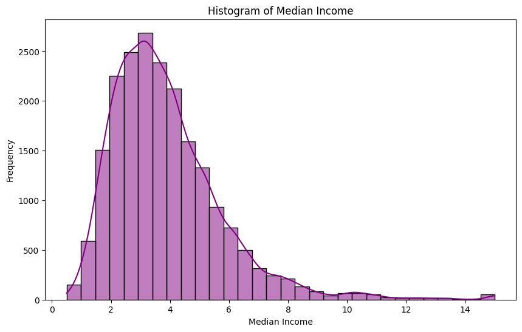

```python
# TASK 1: Creating a histogram for "median_income"
mtb.figure(figsize=(10, 6))

sbn.histplot(data=data, x="median_income", bins=30, kde=True, color='purple')


mtb.title("Histogram of Median Income")

mtb.xlabel("Median Income")

mtb.ylabel("Frequency")

mtb.show()
```

```python
# Capping potential outliers in the "median_income" column
threshold = 10

data['median_income'] = data['median_income'].apply(lambda x: threshold if x > threshold else x)

# output
print(data)
```

```
       longitude  latitude  housing_median_age  total_rooms  total_bedrooms  \
0        -122.74     39.71                16.0        255.0            73.0
1        -117.02     36.40                19.0        619.0           239.0
2        -117.86     34.24                52.0        803.0           267.0
3        -123.17     40.31                36.0         98.0            28.0
4        -118.33     34.15                39.0        493.0           168.0
...          ...       ...                 ...          ...             ...
20635    -118.90     34.14                35.0       1503.0           263.0
20636    -118.69     34.18                11.0       1177.0           138.0
20637    -118.80     34.19                 4.0      15572.0          2222.0
20638    -118.69     34.21                10.0       3663.0           409.0
20639    -118.85     34.27                50.0        187.0            33.0

       population  households  median_income  median_house_value  \
0            85.0        38.0         1.6607             14999.0
```

[output cut: 25 more lines]

[figure not shown]

```python
# TASK 3: Creating a histogram for "housing_median_age"
mtb.figure(figsize=(10, 6))

sbn.histplot(data=data, x="housing_median_age", bins=30, kde=True, color='orange')

mtb.title("Histogram of Housing Median Age")

mtb.xlabel("Housing Median Age")

mtb.ylabel("Frequency")

mtb.show()
```

```python
# TASK 1: Calculating descriptive statistics for numerical features
numerical_features = ['longitude', 'latitude', 'housing_median_age', 'total_rooms', 'total_bedrooms', 'population', 'households', 'median_income', 'median_house_value']

descriptive_stats = data[numerical_features].describe()

# output
print("Descriptive Statistics for Numerical Features:")

print(descriptive_stats)
```

```
Descriptive Statistics for Numerical Features:
          longitude      latitude  housing_median_age   total_rooms  \
count  20640.000000  20640.000000        20640.000000  20640.000000
mean    -119.569704     35.631861           28.633576   2635.944671
std        2.003532      2.135952           12.580816   2181.434626
min     -124.350000     32.540000            1.000000      2.000000
25%     -121.800000     33.930000           18.000000   1448.750000
50%     -118.490000     34.260000           29.000000   2127.000000
75%     -118.010000     37.710000           37.000000   3146.250000
max     -114.310000     41.950000           52.000000  39320.000000

       total_bedrooms    population    households  median_income  \
count    20640.000000  20640.000000  20640.000000   20640.000000
mean       536.838857   1425.546366    499.614729       3.843195
std        419.391878   1132.305245    382.282571       1.780846
min          1.000000      3.000000      1.000000       0.499900
25%        297.000000    788.000000    280.000000       2.563975
50%        435.000000   1166.000000    410.000000       3.535250
75%        643.250000   1724.000000    605.000000       4.742725
max       6445.000000  35682.000000   6082.000000      10.000000

       median_house_value
count        20640.000000
mean        207229.796318
std         115140.438269
min          14999.000000
25%         120800.000000
50%         180400.000000
75%         264725.000000
max         500000.000000
```

```python
# Converting the 'ocean_proximity' values to uppercase and removing leading/trailing whitespaces
data['ocean_proximity'] = data['ocean_proximity'].str.strip().str.upper()

# output
print(data)
```

```
       longitude  latitude  housing_median_age  total_rooms  total_bedrooms  \
0        -122.74     39.71                16.0        255.0            73.0
1        -117.02     36.40                19.0        619.0           239.0
2        -117.86     34.24                52.0        803.0           267.0
3        -123.17     40.31                36.0         98.0            28.0
4        -118.33     34.15                39.0        493.0           168.0
...          ...       ...                 ...          ...             ...
20635    -118.90     34.14                35.0       1503.0           263.0
20636    -118.69     34.18                11.0       1177.0           138.0
20637    -118.80     34.19                 4.0      15572.0          2222.0
20638    -118.69     34.21                10.0       3663.0           409.0
20639    -118.85     34.27                50.0        187.0            33.0

       population  households  median_income  median_house_value  \
0            85.0        38.0         1.6607             14999.0
```

[output cut: 25 more lines]

4. Normalize numerical features using appropriate method based on feature characteristics.

```
        Z-score Normalization (Standardization):
```

```python
from sklearn.preprocessing import StandardScaler

# TASK 1: Starting StandardScaler
scaler = StandardScaler()

# TASK 2: Let's Fit and transform the selected features
data[numerical_features] = scaler.fit_transform(data[numerical_features])

# output
print(data.head())
```

```
   longitude  latitude  housing_median_age  total_rooms  total_bedrooms  \
0  -1.582392  1.909330           -1.003935    -1.091279       -1.103224
1   1.272636  0.359632           -0.765534    -0.924470       -0.709275
2   0.853366 -0.651651            1.856872    -0.840149       -0.642826
3  -1.797018  2.190242            0.585402    -1.163227       -1.210017
4   0.618775 -0.693788            0.823803    -0.982211       -0.877771

   population  households  median_income  median_house_value ocean_proximity
0   -1.183632   -1.207324      -1.163364           -1.667415          INLAND
1   -0.826102   -0.877822      -0.932145           -1.667415          INLAND
2   -0.704277   -0.718302       0.169584           -1.667415          INLAND
3   -1.242779   -1.285776      -1.755336           -1.667415          INLAND
4   -1.030027   -0.945814      -0.791770           -1.645733       <1H OCEAN
```

5. Encode categorical variables using using appropriate method based on feature characteristics.

```python
# TASK 1: Performing one-hot encoding
data_encoded = pd.get_dummies(data, columns=["ocean_proximity"], prefix=["ocean"])

# output
print(data_encoded.head())

print("binary indicator succesfully installed")
```

[output not shown]

6.Engineer one new feature based on existing features.

Feature: Income per capita

```python
# dividing median income by population
data['income_per_capita'] = data['median_income'] / data['population']

# output
print(data[['median_income', 'population', 'income_per_capita']].head())
```

[output not shown]

extra feature: Rooms Per household

```python
# Calculating Rooms per Household
data['rooms_per_household'] = data['total_rooms'] / data['households']

# output
print(data[['rooms_per_household']])
```

```
       rooms_per_household
0                 0.903882
1                 1.053162
2                 1.169682
3                 0.904690
4                 1.038502
...                    ...
20635             0.700039
20636             0.671731
20637             1.371933
20638            -1.399411
20639             0.923694

[20640 rows x 1 columns]
```

```python
# Saving the cleaned dataset to a new CSV file
data.to_csv("C:/Users/91902/Downloads/cleaned_housing_dataset.csv", index=False)

# output
print("Cleaned dataset saved to 'cleaned_housing_dataset.csv'")
```

```
Cleaned dataset saved to 'cleaned_housing_dataset.csv'
```

Descriptive Analytics Tasks : 1. Investigate the distribution of housing prices across different ocean proximities in California.

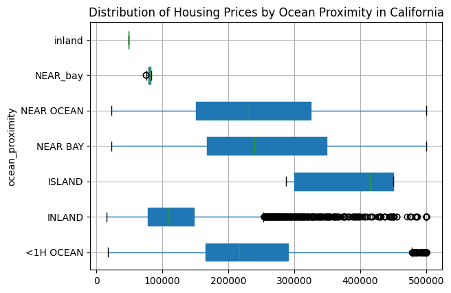

```python
import pandas as pd

import matplotlib.pyplot as plt

# TASK 1: Loading the dataset again
data = pd.read_csv("C:/Users/91902/Downloads/housing_dataset.csv")

# TASK 2: Creating a box plot to visualize the distribution of housing prices
plt.figure(figsize=(10, 6))

boxplot = data.boxplot(column='median_house_value', by='ocean_proximity', vert=False, patch_artist=True)

# TASK 1: plotting titles and labels
plt.title('Distribution of Housing Prices by Ocean Proximity in California')

plt.suptitle('')  # Remove the default title

# Showing plot
plt.show()
```

Analyze the relationship between median income and housing prices.

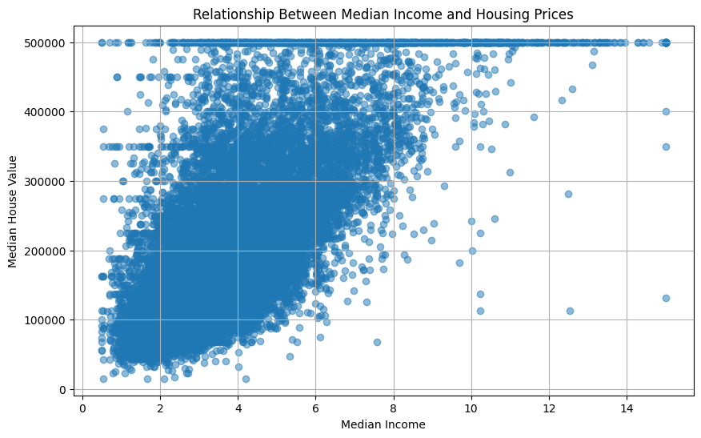

```python
# TASK 1: Creating a scatter plot
plt.figure(figsize=(10, 6))

plt.scatter(data['median_income'], data['median_house_value'], alpha=0.5)

plt.title('Relationship Between Median Income and Housing Prices')

plt.xlabel('Median Income')

plt.ylabel('Median House Value')

plt.grid(True)

# output
plt.show()
```

- Positive correlation: There is a positive correlation between median income and median house value. hence, as median income increases, median house value also tends to increase.
- Non-linear relationship: The relationship between the two variables is not linear, indicating that other factors may also influence housing prices.
- Variation in data: There is a large amount of variation in the data, suggesting that there are areas with the same median income but different median house values.
- We can conclude that while income is a Important factor in housing prices, other factors also play a role.

```python
from sklearn.model_selection import train_test_split

# TASK 1: Loading the Cleaned dataset
cleaned_data = pd.read_csv("C:/Users/91902/Downloads/cleaned_housing_dataset.csv")

# TASK 2: Let's define the features (X) and the target variable (y)
X = cleaned_data.drop(columns=['median_house_value'])

y = cleaned_data['median_house_value']

# TASK 3: Spliting the data into training and testing sets ( 80% training, 20% testing)
X_train, X_test, y_train, y_test = train_test_split(X, y, test_size=0.2, random_state=42)

# output
print("Number of samples in the training set:", len(X_train))

print("Number of samples in the testing set:", len(X_test))
```

```
Number of samples in the training set: 16512
Number of samples in the testing set: 4128
```

2. Train a linear regression model as a baseline model.

```python
from sklearn.impute import SimpleImputer

# TASK 1: Creating an imputer that fills missing values with the mean of each column
imputer = SimpleImputer(strategy='mean')

# TASK 2: Fitting the imputer on the training data
X_train_encoded_imputed = imputer.fit_transform(X_train_encoded)

X_test_encoded_imputed = imputer.transform(X_test_encoded)

# output
print("missing values Imputed")
```

```
missing values Imputed
```

```python
# TASK 1: for extra safetry Removing rows with missing values
X_train_encoded = X_train_encoded.dropna()

y_train = y_train[X_train_encoded.index]

X_test_encoded = X_test_encoded.dropna()

y_test = y_test[X_test_encoded.index]

# TASK 1: fitting the model
baseline_model.fit(X_train_encoded, y_train)
```

```
LinearRegression()
```

```python
# baseline model
from sklearn.linear_model import LinearRegression

from sklearn.metrics import mean_squared_error, r2_score

# TASK 1: Creating and training the linear regression model
baseline_model = LinearRegression()

baseline_model.fit(X_train_encoded, y_train)

# TASK 2: Making predictions on the testing data
y_pred_baseline = baseline_model.predict(X_test_encoded)

# TASK 3: Calculating MSE
mse_baseline = mean_squared_error(y_test, y_pred_baseline)

# TASK 4: Calculating R²
r2_baseline = r2_score(y_test, y_pred_baseline)

mse_baseline, r2_baseline
```

```
(2.1977975706737598e-12, 0.9999999999977839)
```

A very low MSE and a high R² score close to 1 indicates that the model is performing very well on the data, with almost perfect predictions. we can conclude that this is a strong baseline model.

3. Print the learned coefficients (weights) of the model.

```python
# TASK : Printing weights of the model

coefficients = baseline_model.coef_

print("Coefficients (Weights):")
for feature, coef in zip(X_train_encoded.columns, coefficients):
    print(f"{feature}: {coef}")
```

```
Coefficients (Weights):
longitude: -5.386102337674272e-07
latitude: -5.279102996205709e-07
housing_median_age: -1.4923323806971543e-07
total_rooms: 4.365885218904144e-07
total_bedrooms: -4.68754378869464e-07
population: -1.994039419087556e-07
households: 2.856352164509664e-07
median_income: -2.431614249755236e-07
z_score: 1.0018620683944877
income_per_capita: -5.018809358833227e-10
rooms_per_household: 3.960373542912735e-10
ocean_proximity_<1H OCEAN: 4.0826197651903646e-08
ocean_proximity_INLAND: -5.314579478186022e-07
ocean_proximity_ISLAND: 1.9127716738065234e-06
ocean_proximity_NEAR BAY: -1.3801705843287899e-08
ocean_proximity_NEAR OCEAN: -1.7686716233472566e-07
ocean_proximity_NEAR_BAY: -1.2314710557311738e-06
```

```
     a.Comment on which feature the model gave higher weight to in the weight vector.
```

The feature that the model gave the most importance in predicting house prices is "z_score." This feature has a much higher impact compared to others in determining the house's value. In simpler terms, the model thinks that "z_score" is the most important factor when deciding how much a house is worth.

4. Evaluate the model's performance on the test set using the following metrics:

   ```
    a.   Mean Absolute Error (MAE)

    b.   Mean Squared Error (MSE)
   ```

```python
from sklearn.metrics import mean_absolute_error, mean_squared_error

# TASK 1: Calculating MAE
mae = mean_absolute_error(y_test, y_pred_baseline)

# TASK 2: Calculating MSE
mse = mean_squared_error(y_test, y_pred_baseline)

# output
print("Mean Absolute Error (MAE):", mae)

print("Mean Squared Error (MSE):", mse)
```

```
Mean Absolute Error (MAE): 8.86676832363723e-07
Mean Squared Error (MSE): 2.1977975706737598e-12
```

- The very low values for both MAE and MSE indicate that the model is performing exceptionally well, with very small errors in its predictions on the test set.
5. Try 2 other regression algorithms and compare their performance to the linear regression baseline.

```python
#Random Forest Regressor (RFR)
from sklearn.ensemble import RandomForestRegressor

# TASK 1: Creating and training the RFR model
random_forest_model = RandomForestRegressor(random_state=42)

random_forest_model.fit(X_train_encoded, y_train)

# TASK 2: Making predictions on the testing data
y_pred_random_forest = random_forest_model.predict(X_test_encoded)

# TASK 3: Evaluating the Random Forest model
mae_random_forest = mean_absolute_error(y_test, y_pred_random_forest)

mse_random_forest = mean_squared_error(y_test, y_pred_random_forest)

#OUTPUT
print("Random Forest Regressor Performance:")

print(f"Mean Absolute Error (MAE): {mae_random_forest}")

print(f"Mean Squared Error (MSE): {mse_random_forest}")
```

```
Random Forest Regressor Performance:
Mean Absolute Error (MAE): 0.00016493627133892585
Mean Squared Error (MSE): 6.31792869552479e-07
```

```python
# Support Vector Regressor (SVR)
from sklearn.svm import SVR

# TASK 1: Creating and training the SVR model
svr_model = SVR()

svr_model.fit(X_train_encoded, y_train)

# TASK 2: let's Make predictions on the testing data
y_pred_svr = svr_model.predict(X_test_encoded)

# TASK 3: Evaluating the SVR model
mae_svr = mean_absolute_error(y_test, y_pred_svr)

mse_svr = mean_squared_error(y_test, y_pred_svr)

#output
print("Support Vector Regressor (SVR) Performance:")

print(f"Mean Absolute Error (MAE): {mae_svr}")

print(f"Mean Squared Error (MSE): {mse_svr}")
```

```
Support Vector Regressor (SVR) Performance:
Mean Absolute Error (MAE): 0.07500226300431694
Mean Squared Error (MSE): 0.018194884656395783
```

```
     a. Provide a reasonable explanation on why the results are different between the linear regression model and the other models
```

- the SVR model seems to have higher errors compared to both Linear Regression and Random Forest Regressor.
- Therefore, we can conclude that the Linear Regression model is the most suitable choice among the three regression algorithms.